# Info1A-MPSI-PCSI_TP12_corrigé

## TP12 : complexité

- Éléments de cours sur : modules et importation de modules (préliminaire 1, ci-dessous)
- Éléments de cours sur : représentations graphiques (préliminaire 2, ci-dessous)
- Éléments de cours sur : complexité, (ici, en introduction).

Raccourcis pour Jupyter :

- Maj + Enter : exécute la cellule courante ;
- Esc b : crée une cellule de code au-dessous de la cellule courante ('b' pour 'below') ;
- Alt + Enter : exécute la cellule courante et créé une cellule de code à sa suite ;
- Esc + m : transforme une cellule de code (mode 'Code') en cellule de texte (mode 'Markdown') ;
- Esc + y : transforme cellule de texte (mode 'Markdown') en une cellule de code (mode 'Code').

## Préliminaire 1

Nous allons utiliser dans ce TP différents modules proposés nativement en Python 3.  
On rappelle que dans le **[programme de 1ère année](https://cache.media.education.gouv.fr/file/SPE1-MEN-MESRI-4-2-2021/27/2/spe774_annexe_1373272.pdf)** :

«Aucune connaissance sur un module particulier n’est exigible des étudiants.  
Toute utilisation d’autres éléments du langage que ceux que liste cette annexe, ou d’une fonction d’un module, doit obligatoirement être accompagnée de la documentation utile, sans que puisse être attendue une quelconque maîtrise par les étudiants de ces éléments.»

Cependant, on comprendra qu'il est attendu que les candidats soient à même d'utiliser toute fonction d'un module, pourvu que sa spéficiation et la syntaxe des appels à cette fonction aient été données au candidat, par exemple sous la forme d'une docmument (éventuellement en anglais), et/ou sous la forme d'exemples d'appel(s) à cette fonction.

On rappelle *a contrario* que le programme, dans son **Annexe A**, stipule, que **les éléments suivants du langage Python sont exigibles** :

- **Importation de modules avec** `import` *module*, `import` *module* `as` *alias*, `from module import` $f, g, \ldots$.

Voici les quatre façons d'importer des fonctions (ou des constantes) qui sont à connaître, illlustrées par des exemples déjà rencontrés, en TP d'informatique ou en phyisque ou en SII.

- mise à disposition du module entier, avec nécessité de préfixer le nom des fonctions ou constantes du module par le nom du module :

```python
import math ## <-- permet d'accéder à toutes les fonctions et constantes du module math
```

```python
## exemple d'appel à des éléments du module (fonction cos et sin et constante, valeur approchée de pi)
math.cos(math.pi / 3) ** 2 + math.sin(math.pi / 3) ** 2
```

```
1.0
```

On a dû faire précéder (préfixer) le nom de chaque fonction et le nom de la constante `pi` par le nom du module.

- mise à disposition du module entier, avec nécessité de préfixer le nom des fonctions ou constantes du module par l' *alias* choisi pour le nom du module :

```python
import numpy as np ## <-- permet d'accéder à toutes les fonctions et constantes du module numpy via l'alias np
```

```python
## exemple d'appel à un élément du module, ici la fonction linspace, produisant une subdivision régulière
## d'un intervalle [a, b])
np.linspace(0, 1, 5)
```

```
array([0.  , 0.25, 0.5 , 0.75, 1.  ])
```

On a dû préfixer le nom de la fonction `linspace` par l'alias `np`, défini en remplacement du nom du module par l'ajout de `as np` après `import numpy`.

- importation de toutes les éléments du module, sans nécessité de préfixer

```python
from math import *
```

Toutes les éléments du module sont disponibles, en les invoquant par leur nom seul, sans préfixer :

```python
log(e), log2(2), log(8, 2)
```

```
(1.0, 1.0, 3.0)
```

- importation d'éléments spécifiques du module, éventuellement énumérés dans une séquence les autres éléments du module seront indisponibles

```python
from math import ceil, floor
```

```python
ceil(-1.2), floor(-1.2)
```

```
(-1, -2)
```

On peut mentionner, pour finir, la possibibilité d'importer un élément du module, en lui attribuant un alias (l'élément ne sera pas disponible sous son nom original) :

```python
from string import ascii_lowercase as alphabet
```

```python
alphabet
```

```
'abcdefghijklmnopqrstuvwxyz'
```

```python
ascii_lowercase
```

```
---------------------------------------------------------------------------
NameError                                 Traceback (most recent call last)
~\AppData\Local\Temp/ipykernel_2052/17404345.py in <module>
----> 1 ascii_lowercase

NameError: name 'ascii_lowercase' is not defined
```

## Préliminaire 2

On redonne ici quelques façons élémentaires de produire des représentations graphiques à l'aide de [`matplotlib`](https://matplotlib.org/).

**Fondamentalement**, pour effectuer un tracé à l'aide de `matplotlib`, il faut fournir une ensemble de points à placer, *sous la forme de la liste des abscisses de ces points et de la liste des ordonnées de ces points*.

- tracer un triangle

Voici pour tracer le triangle ABC, de sommets reliant les points $A (-1, -1)$, $B (3, 1)$ et $C (2, 4)$.

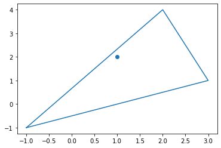

```python
import matplotlib.pyplot as plt ## importation du module ad hoc avec pour alias plt

fig, ax = plt.subplots() ## création de la figure et du système d'axes
plt.scatter([1], [2]) # on construit ici le point de coordonnées $(1, 2)$
plt.plot([-1, 3, 2, -1], [-1, 1, 4, -1]) ## ici on consruit le triangle, en donnant en argument de la fonction plot,
                                         ## la liste des abscisses des points à relier par une ligne brisée,
                                         ## [x_A, x_B, x_C, x_A], et la liste de leurs ordonnées, [y_A, y_B, y_C, y_A].
plt.show() ## cette instruction déclenche l'affichage de la figure.
```

- représentation graphique d'une suite

Pour représenter graphiquement les termes d'une suite, on devra ainsi se donner une liste (croissante !) des valeurs de $n$ à prendre en compte, et une liste des valeurs correspondante des termes de rang $n$ de la suite à représenter.

Ainsi, pour représenter les 10 premiers termes de la suite $u_=(u_n)_{n\geqslant 0}=(cos(n))_{n\geqslant 0}$, on pourra procéder comme suit, en utilisant, par exemple, des listes construites par compréhension.

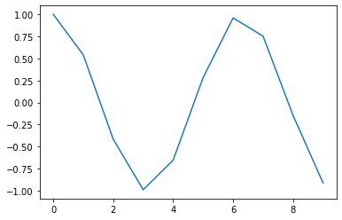

```python
import matplotlib.pyplot as plt ## importation du module ad hoc avec pour alias plt

import math

fig, ax = plt.subplots() ## création de la figure et du système d'axes

nmax = 10
Ln = [n for n in range(nmax)] # liste des 10 valeurs de n, de 0 à 9 (inclus)
Lu = [math.cos(n) for n in range(nmax)] # liste des 10 valeurs de cos(n), pour n variant de, de 0 à 9 (inclus)

## constrution de la représentation graphique

plt.plot(Ln, Lu)

plt.show() ## cette instruction déclenche l'affichage de la figure.
```

Si l'on souhaite que les points de la représentation graphique ne soient pas reliés par des segments (ce qui est le cas par défaut), on pourra, par exemple, utiliser la fonction `scatter`, au lieu de la fonction `plot`.

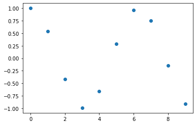

```python
import matplotlib.pyplot as plt
import math

fig, ax = plt.subplots()

Ln, Lu = [n for n in range(10)], [math.cos(n) for n in range(10)]

plt.scatter(Ln, Lu)
plt.show()
```

Il n'est pas attendu ici de compétences de votre part au-delà du tracé de courbes ou de nuages de points.

## Introduction

Le premier exercice porte sur l'aptitude à utiliser des fonctions issues de modules, dans le but de valider le modèle théorique de calcul de complexité temporelle.  
Les autres exercices sont pour donner les outils pour les calculs de complexité exigés dans le cadre du programme. Vous y trouverez des illustrations graphiques et numériques, mais ce sont bien les raisonnements et les calculs qui sont des attendus du programme et non les outils de vérification expérimentale.

On pourra utilement trouver [ici](https://fr.wikipedia.org/wiki/Complexit%C3%A9_en_temps), les noms donnés aux différents ordres de grandeur de complexité, avec des exemples d'algorithmes ayant ces complexité (*cf.* tableau «*Liste de complexités en temps classiques*»), et trouver [ici](https://fr.wikipedia.org/wiki/Analyse_de_la_complexit%C3%A9_des_algorithmes#Complexit%C3%A9,_comparatif) un comparatif de l'évolution du temps de calcul selon l'ordre de grandeur de la complexité d'un algorithme.

**À faire pendant le temps du TP :**

- première heure : Exercices 1 et 2;
- deuxième heure : Exercice 3

# Partie I $\quad$ Simulations

## Exercice 1 Mesure de temps d'exécution des opérations élémentaires

Afin de mieux appréhender les hypothèses du modèle abstrait retenu dans le cours pour aborder la complexité temporelle d'un algorithme, on se propose ici de mesurer le temps d'exécution de certaines opérations en Python.

On rappelle l'existence, dans le module `time`, d'une fonction `time`, renvoyant le [nombre de secondes écoulées depuis le 1er janvier 1970](https://fr.wikipedia.org/wiki/Epoch) :

```python
from time import time
tepoch = time()
print(tepoch)
```

```
1650516725.5689037
```

**Q1** À l'aide de votre montre ou téléphone, vérifiez, en exécutant les deux cellules suivantes, en respectant un intervalle de 5 secondes entre les deux éxécutions, la validité de la mesure de la durée d'un intervalle de temps par différence entre les valeurs renvoyées par la fonction `time` :

```python
from time import time
t0 = time()
```

Cinq secondes après avoir exécuté la cellule ci-dessus, 10 secondes,exécuter la seconde cellule, ci-dessous :

```python
t1 = time()
print(t1 - t0)
```

```
0.4378647804260254
```

Vous venez d'effectuer votre première mesure d'un temps écoulé à l'aide de Pyhton.

- Précision de la mesure

On peut obtenir la régularité de la mise à jour des valeurs prises par la fonction `time` avec l'instruction suivante :

```python
import time
time.get_clock_info('time')
```

```
namespace(implementation='GetSystemTimeAsFileTime()',
          monotonic=False,
          adjustable=True,
          resolution=0.015625)
```

Or, la fréquence des processeurs actuels étant de l'ordre du gigahertz, un processeur peut exécuter de l'ordre de $10^9$ opérations élémentaires par secondes sur des mots de 32 ou 64 bits, aussi le temps d'exécution d'une opération élémentaire par le processeur est de l'ordre de $10{-9}$ secondes, bien en deçà de la résolution de la fonction `time`.

```python
import time
time.get_clock_info('perf_counter')
```

```
namespace(implementation='QueryPerformanceCounter()',
          monotonic=True,
          adjustable=False,
          resolution=1e-07)
```

La fonction `perf_counter` mesure le temps écoulé en secondes, depuis un instant non connu, mais postérieur au démarrage ou au dernier redémarrage du noyau Python.

**Q2**

À l'aide de deux appels à la fonction `perf_counter`, mesurer le temps écoulé en nanosecondes pendant l'exécution du calcul de la somme $1+1$.  
Commenter le résultat de la mesure.

```python
from time import perf_counter

t0 = perf_counter()
1 + 1
...
```

```
Ellipsis
```

*Q2 corrigé*

```python
from time import perf_counter

t0 = perf_counter()
1 + 1
t1 = perf_counter()
duree = t1 - t0
print(duree)
```

```
3.510000000517266e-05
```

À l'aide de deux appels à la fonction `perf_counter`, mesurer le temps écoulé en nanosecondes pendant l'exécution du calcul de la somme $1+1$.  
Commenter le résultat de la mesure.

```python
from time import perf_counter

t0 = perf_counter()
1 + 1
...
```

```
Ellipsis
```

*Q2 corrigé*

```python
from time import perf_counter

t0 = perf_counter()
1 + 1
t1 = perf_counter()
duree = t1 - t0
print(duree)
```

```
5.170000000020991e-05
```

```python
print(format(duree, '.60f'))
```

```
0.000051700000000209911377169191837310791015625000000000000000
```

**Q3**

Les mesures de temps d'exécution sont perturbées par le fait que le processeur est sollicité en permanence pour effectuer d'autres tâches que l'exécution de l'algorithme dont on mesure le temps d'exécution.  
Aussi même lors d'une mesure de temps élémentaire, celle-ci peut être perturbée.

Répéter, à l'aide d'une boucle `while`, la mesure du temps d'execution pour le calcul de $1+1$, jusqu'à obtenir une durée non nulle.  
On affichera la durée non nulle mesurée et on ajoutera un compteur afin d'afficher le nombre de mesures ayant été faites pour enfin obtenir une durée non nulle.  
Commenter.

```python
from time import perf_counter

...
```

```
Ellipsis
```

*Q3 corrigé*

```python
from time import perf_counter

compteur = 0

d = 0.
while d == 0:
    t0 = perf_counter()
    1 + 1
    t1 = perf_counter()
    d = t1 - t0
    compteur += 1
print(d, compteur)
```

```
5.000000129484761e-07 1
```

**Q4**

À l'aide d'une boucle `for`, répéter $N=1000000$ fois (un million de fois) la mesure précédente (temps de calcul de $1+1$), et afficher le pourcentage de mesures non nulles, la moyenne des temps d'éxécutions mesurés (incluant les mesures nulles), et le nombre moyen de mesures nulles entre deux mesures non nulles.  
*On n'utilisera pas de listes pour effectuer ces calculs.*

```python
N = 1000000

somme_des_durees = 0
nombre_de_mesures_non_nulles = 0
S = 0 # S sera la somme des nombre de mesures nulles entre deux mesures non nulles
compteur_mesures_nulles_consecutives = 0 # sera réinitialisé à chaque mesure non nulle, incrémenté de 1 sinon
for i in range(N):
    ...











## fin de boucle
print("Pourcentage de mesures non nulles :", ...)
print("Moyenne des temps d'exécution mesurés :", ...)
print("Nombre moyen de mesures non nulles entre deux mesures non nulles :", ...)
```

```
Pourcentage de mesures non nulles : Ellipsis
Moyenne des temps d'exécution mesurés : Ellipsis
Nombre moyen de mesures non nulles entre deux mesures non nulles : Ellipsis
```

*Q4 corrigé*

```python
from time import perf_counter

N = 1000000

somme_des_durees = 0
nombre_de_mesures_non_nulles = 0
S = 0 # S sera la somme des nombre de mesures nulles entre deux mesures non nulles
compteur_mesures_nulles_consecutives = 0 # sera réinitialisé à chaque mesure non nulle, incrémenté de 1 sinon
for i in range(N):
    t0 = perf_counter()
    1 + 1
    t1 = perf_counter()
    d = t1 - t0
    ## traitement de la mesure
    somme_des_durees = somme_des_durees + d
    if d > 0:
        nombre_de_mesures_non_nulles += 1
        S = S + compteur_mesures_nulles_consecutives
        compteur_mesures_nulles_consecutives = 0 # réinitialisation du compteur
    else:
        compteur_mesures_nulles_consecutives +=1
## fin de boucle
print("Pourcentage de mesures non nulles :", nombre_de_mesures_non_nulles / N * 100)
print("Moyenne des temps d'exécution mesurés :", somme_des_durees / N)
print("Nombre moyen de mesures non nulles entre deux mesures non nulles :", S / nombre_de_mesures_non_nulles)
```

```
Pourcentage de mesures non nulles : 92.4649
Moyenne des temps d'exécution mesurés : 1.039146000048845e-07
Nombre moyen de mesures non nulles entre deux mesures non nulles : 0.08149146324713485
```

En exécutant plusieurs fois la cellule ci-dessus, on peut constater que le temps moyen mesuré est stable (les perturbations des mesures existent, mais affectent les mesures de façon "prédictible").

**Q5**

Dans le modèle de calcul de complexité, on a considéré l'addition de deux entiers comme une opération élémentaire.  
Or l'addition de deux entiers par le processeur est, en soi, une opération qui s'éxécute bit à bit sur la représentation binaire des entiers à additionner (de façon tout-à-fait comparable à l'addition *à la main* en base dix que l'on apprend à faire à l'école primaire, qui se fait *chiffre à chiffre*).  
Python permettant d'additionner des entiers de taille quelconque, avec la garantie d'un résultat exact, il doit bien y avoir une taille d'entier (en nombre de bits), à partir de laquelle le temps d'exécution de l'addition ne peut plus être considérée comme une opération élémentaire.

**Q5.a**

Écrire une fonction `temps_moyen`, qui calcule et renvoie la durée moyenne du calcul de la somme de deux entiers $n_1$ et $n_2$ sur $m$ calculs de la somme $n_1+n_2$.  
Tester la fonction pour des entiers supérieurs à un million, et pour $m=100$, $m=1000$ et $m= 10000$.

```python
def temps_moyen(n1, n2, m):
    ...
```

*Q5.a*

```python
def temps_moyen(n1, n2, m):
    from time import perf_counter
    s = 0
    for i in range(m):
        t0 = perf_counter()
        1 + 1
        t1 = perf_counter()
        d = t1 - t0
        s += d
    return s / m
```

- tests

```python
n1, n2 = 546863841, 133548434
for m in (100, 1000, 10000):
    print(temps_moyen(n1, n2, m))
```

```
1.640000007796516e-07
9.039999973481372e-08
9.105000005007468e-08
```

**Q5.b**

On rappelle ici que l'écriture binaire d'un entier naturel $n$ est unique et à la forme suivante : $$n = \sum_{k=0}^{m-1}c_k2^k,$$ où les nombres $c_k$ correspondent aux chiffre de l'écriture en base 2 de $n$ et sont tels que $c_{m-1}=1$ et $c_0, c_1, \ldots, c_{m-2}$ sont des entiers égaux à 0 ou à 1.
$m$ est donc le nombre de chiffres de l'écriture en base 2 de $n$, et on note $\left(c_{m-1}\ldots c_1 c_0\right)_2$ l'écriture en base 2 de $n$.

Par exemple, l'écriture en base 2 de $11$, est $(1011)_2$, ce qui signifie que l'écriture en base 2 de $11$, est $\left(c_3c_2c_1c_0\right)_2$ avec $c_0=1, c_1=1, c_2=0, c_3=1$. Le nombre de chiffres en base 2 de $11$ est $m=4$.

Pour un nombre de chiffres $m$ donné, le plus petit entier à $m$ chiffres est l'entier $n_{\min}= 2^{m-1}$ et le plus grand est $n_{\max}= \sum_{k=0}^{m-1}2^k=\frac{1-2^m}{1-2}=2^m-1$.  
Par exemple, le plus petit entier naturel dont l'écriture binaire comporte $4$ chiffres est $2^3=8$ et le plus grand est $2^4-1=15$.

On peut obtenir en Python l'écriture binaire d'un entier naturel $n$, par appel à la fonction `bin` :

```python
bin(8), bin(11), bin(15)
```

```
('0b1000', '0b1011', '0b1111')
```

Définir une fonction `entiers_alea(m)`, renvoyant deux entiers dont l'écriture en base 2 comporte exactement $m$ chiffres.  
On fera appel à la fonction `randrange`, dont on rappelle la documentation.

```python
import random

help(random.randrange)
```

```
Help on method randrange in module random:

randrange(start, stop=None, step=1) method of random.Random instance
    Choose a random item from range(start, stop[, step]).

    This fixes the problem with randint() which includes the
    endpoint; in Python this is usually not what you want.
```

```python
def entiers_alea(m):
    ...
```

*Q5.b corrigé*

```python
def entiers_alea(m):
    a, b = 2**(m - 1), 2**m
    return random.randrange(a, b), random.randrange(a, b)
```

- test

```python
entiers_alea(4), entiers_alea(10), entiers_alea(100)
```

```
((9, 14),
 (857, 967),
 (689080890350720641733252656861, 938873629770653990134903410590))
```

**Q5.c**

```python
p = 0
...
```

*Q5.c corigé*

```python
p = 0
dmoy = 0
while dmoy < 1e-5:
    n1, n2 = entiers_alea(10**p)     ## tirage (pseudo-)aléatoire de deux entiers à 10^p chiffres en base 2
    dmoy = temps_moyen(n1, n2, 100) ## temps moyen d'éxécution sur 1000 mesures
    p += 1 ## incrémentation de p
## fin de boucle
print("Nombre de chiffres en base 2 pour les deux entiers additionnés :", 10**p)
print("Temps moyen d'exécution de l'addition sur 1000 mesures :", dmoy)
```

[output not shown]

## Exercice 2 $\quad$ Évolution du temps d'exécution en fonction de la taille de l'instance

On prend ici comme exemple emblématique d'algorithme dont la complexité est linéaire, le calcul d'une somme de $n$ entiers égaux à $1$.

**Q1** Écrire une fonction `s` de paramètre $n$ et effectuant le calcul d'une somme de $n$ entiers égaux à 1. La fonction pourra ne rien renvoyer, l'objectif n'étant, à terme, que de mesurer le temps de calcul de la somme en fonction de $n$.

```python
def s(n):
    ...
```

*Q1 corrigé*

```python
def s(n):
    s = 0 # variable locale s initialisée à 0
    for i in range(n):
        s = s + 1
```

**Q2**

Écrire une fonction `temps_min`, de paramètres $f$, $n$ et $m$, où $f$ est une fonction à un paramètre, entier, et $n$ et $m$ deux entiers naturels, et qui renvoie le temps d'exécution minimum observé pour $m$ appels à $f$ avec $n$ en paramètre de $f$.

On utilisera pour déterminer ce temps minimum une variable `tmin`, initialisée à la valeur flottante *infinie*, `float('inf')`, qui est une valeur de type flottant, sans signification concrète, mais ayant la propriété d'être supérieure strictement à tout autre valeur flottante.  
Le recours à la fonction `min` est autorisé pour déterminer le minimum entre deux valeurs flottantes.

*Le fait de ne retenir que le temps minimum d'exécution au cours des $m$ tests permet de s'abstraire autant que faire se peut des temps de calculs allongés par le partage du processeur avec tâches autres que notre calcul de somme.*

```python
def temps_min(f, n, m):
    from time import perf_counter
    tmin = float('inf')
    ...

    return tmin
```

*Q2 corrigé*

```python
def temps_min(f, n, m):
    from time import perf_counter
    tmin = float('inf')
    for i in range(m):
        t0 = perf_counter()
        f(n)
        t1 = perf_counter()
        tmin = min(tmin, t1 - t0)
    return tmin
```

- test

```python
temps_min(s, 10**4, 10), temps_min(s, 10**4, 100)
```

```
(0.000473000000056345, 0.0003575000000637374)
```

En exécutant plusieurs fois la cellule ci-dessus, on observe que le temps minimum observé n'est que marginalement inférieur pour $100$ simulations plutôt que $10$, aussi en première approximation, on pourra se limiter à 10 simulations par la suite.

**Q3**

On souhaite effectuer des mesures de temps d'exécution pour des tailles d'instances, $n$, dans un intervalle d'entiers $[\![a, b]\!]$, sans cependant tester toutes les $b -a +1$ valeurs de cet intervalle, afin que les simulations ne prennent pas un temps déraisonnable.

**Q3.a**

Rappeler comment on peut construire, à l'aide d'une boucle `while`, la liste de toutes les valeurs entières de la forme $a + kc$, $c>0$, éléments d'un intervalle $[\![a, b]\!]$.  
On définira une fonction `échantillonnage(a, b, c)`, renvoyant une telle liste pour des valeurs entières données, $a, b$ et $c$, telles que $0\leqslant a \leqslant b$ et $c>0$.

```python
def echantillonnage(a, b, c):
    L = []
    x = a
    while ...:
        L.append(x)
        ...
    return L
```

*Q3.a corrigé*

```python
def echantillonnage(a, b, c):
    L = []
    x = a
    while x < b + 1:
        L.append(x)
        x = x + c
    return L
```

- tests

```python
echantillonnage(2, 17, 3)
```

```
[2, 5, 8, 11, 14, 17]
```

**Q3.b**

Par quel appel à la fonction `echantillonnage` peut-on générer une liste de 101 valeurs entières régulièrement réparties dans un intervalle de la forme $[\![0, 10^p]\!]$ pour $p\geqslant 2$, *i.e.* la liste des valeurs $[0, 10^{p-2}, 2.10^{p-2}, \ldots 10^p]$ ?

```python
...
```

```
Ellipsis
```

Généraliser pour obtenir $m+1$ valeurs entières régulièrement réparties dans un intervalle de la forme $[\![0, M]\!]$, où $M$ est un multiple de $m$.

```python
...
```

```
Ellipsis
```

Vérifier, sur l'exemple, que l'on obtient bien le même résultat que par la méthode suivante (avec une utilisation de `range` *a priori* hors-programme)

```python
M, m = 50, 5
[i for i in range(0, M + 1, M // m)]
```

```
[0, 10, 20, 30, 40, 50]
```

```python
...
```

```
Ellipsis
```

*Q3.b corrigé*

```python
p = 100
echantillonnage(0, p, p // 100)
```

```
[0,
 1,
 2,
 3,
 4,
 5,
 6,
 7,
 8,
 9,
 10,
 11,
 12,
 13,
 14,
 15,
 16,
 17,
 18,
 19,
 20,
 21,
 22,
 23,
 24,
 25,
 26,
 27,
 28,
 29,
 30,
 31,
 32,
 33,
 34,
 35,
 36,
 37,
 38,
 39,
```

[output cut: 46 more lines]

```
 86,
 87,
 88,
 89,
 90,
 91,
 92,
 93,
 94,
 95,
 96,
 97,
 98,
 99,
 100]
```

```python
p = 10**6
echantillonnage(0, p, p // 100)
```

```
[0,
 10000,
 20000,
 30000,
 40000,
 50000,
 60000,
 70000,
 80000,
 90000,
 100000,
 110000,
 120000,
 130000,
 140000,
 150000,
 160000,
 170000,
 180000,
 190000,
 200000,
 210000,
 220000,
 230000,
 240000,
 250000,
 260000,
 270000,
 280000,
 290000,
 300000,
 310000,
 320000,
 330000,
 340000,
 350000,
 360000,
 370000,
 380000,
 390000,
```

[output cut: 46 more lines]

```
 860000,
 870000,
 880000,
 890000,
 900000,
 910000,
 920000,
 930000,
 940000,
 950000,
 960000,
 970000,
 980000,
 990000,
 1000000]
```

- Généralisation

```python
M, m = 50, 5
echantillonnage(0, M, M // m)
```

```
[0, 10, 20, 30, 40, 50]
```

Pour la suite, on autorise d'utiliser la fonction `echantillonnage` pour construire de telles listes, mais on autorise aussi d'utiliser un appel à `range` avec les trois paramètres $a, b$ et $c$ et des compréhensions de liste :

```python
p = 100
[i for i in range(0, p + 1, p // 100)]
```

```
[0,
 1,
 2,
 3,
 4,
 5,
 6,
 7,
 8,
 9,
 10,
 11,
 12,
 13,
 14,
 15,
 16,
 17,
 18,
 19,
 20,
 21,
 22,
 23,
 24,
 25,
 26,
 27,
 28,
 29,
 30,
 31,
 32,
 33,
 34,
 35,
 36,
 37,
 38,
 39,
```

[output cut: 46 more lines]

```
 86,
 87,
 88,
 89,
 90,
 91,
 92,
 93,
 94,
 95,
 96,
 97,
 98,
 99,
 100]
```

```python
p = 10**6
[i for i in range(0, p + 1, p // 100)]
```

```
[0,
 10000,
 20000,
 30000,
 40000,
 50000,
 60000,
 70000,
 80000,
 90000,
 100000,
 110000,
 120000,
 130000,
 140000,
 150000,
 160000,
 170000,
 180000,
 190000,
 200000,
 210000,
 220000,
 230000,
 240000,
 250000,
 260000,
 270000,
 280000,
 290000,
 300000,
 310000,
 320000,
 330000,
 340000,
 350000,
 360000,
 370000,
 380000,
 390000,
```

[output cut: 46 more lines]

```
 860000,
 870000,
 880000,
 890000,
 900000,
 910000,
 920000,
 930000,
 940000,
 950000,
 960000,
 970000,
 980000,
 990000,
 1000000]
```

**Q4**

On souhaite vérifier par l'expérience que le temps de calcul d'une somme de $n$ entiers égaux à $1$ a une complexité linéaire en fonction de $n$, *i.e* approximativement proportionnelle à $n$.

Écrire un script construisant la liste `Lt` des temps de calcul minimums, sur 10 simulations, obtenus par appel à la fonction `temps_min`, pour calculer les sommes $\sum_{k=0}^n 1$ pour $n$ variant de $0$ à $N = 100000$, par pas de $1000$.  
Construire et afficher ensuite la représentation graphique de ces temps d'exécutions, en fonction de $n$.  
*Note : il faudra donc construire aussi une liste, `Ln`, des valeurs de $n$ correspondant à ces temps d'exécutions mesurés.*

Indiquer si la représentation graphique obtenue est compatible avec les attendus.

```python
N = 100000
Ln = ...
Lt = ...
...
```

```
Ellipsis
```

[figure not shown]

```python
import matplotlib.pyplot as plt

fig, ax = plt.subplots()

...


plt.show()
```

*Q4 corrigé*

```python
from time import perf_counter
temps_debut = perf_counter() ## ajout pour obtenir le temps nécessaire à la simulation

N = 100000
Ln = echantillonnage(0, N, N // 100) ## la liste comporte 101 valeurs

Lt = []
for n in Ln:
    Lt.append(temps_min(s, n, 10))

print("Temps pris par la simulation :", perf_counter() - temps_debut)
```

```
Temps pris par la simulation : 3.0305572000000893
```

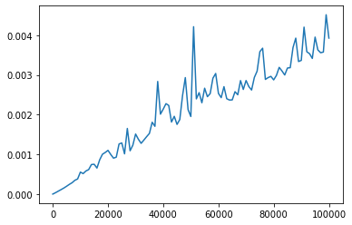

```python
import matplotlib.pyplot as plt

fig, ax = plt.subplots()

plt.plot(Ln, Lt)
plt.show()
```

La représentation graphique obtenue semble compatible avec une complexité linéaire.

On peut conforter cette idée, en calculant la moyenne $A$ des rapports $t_n/n$, où $t_n$ est le temps retenu pour les simulations de paramètere $n>0$, pour toutes les simulations, et en construisant la liste, `Lt1`, des temps $t'_n=A.n$ pour toutes les valeurs de $n>0$ utilisées dans les simulations, et en superposant ces temps au graphique précédent :

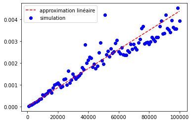

```python
A = sum([Lt[i] / Ln[i] for i in range(1, len(Ln))]) / len(Ln)
Lt1 = [A * Ln[i] for i in range(1, len(Ln))]

import matplotlib.pyplot as plt

fig, ax = plt.subplots()

plt.scatter(Ln[1:], Lt[1:], marker = "o", color = 'blue', label = "simulation")
plt.plot(Ln[1:], Lt1, linestyle = '--', color = 'red', label = "approximation linéaire")

plt.legend()
plt.show()
```

On peut en complément s'en assurer en faisant appel au module `scipy.stats` et sa fonction [`linregress`](https://physique-chimie-python.readthedocs.io/fr/latest/3_SciPy/3_scipy.html) qui donne les coefficient directeur, $a$, et l'ordonnée à l'origine, $b$, de la droite approchant au mieux l'ensemble des points obtenus, au sens des moindres carrés. L'alignement des points du nuage sur la droite est d'autant meilleur que la valeur de $\rho$ (`rho`) est proche de 1 (ceci est hors-programme en informatique, mais peut-être pas en physique) :

```python
len(Ln), len(Lt)
```

```
(101, 101)
```

```python
##import numpy as np
##import matplotlib.pyplot as plt
##from scipy.stats import linregress
##
##a, b, rho ,_ ,_ = linregress(Ln, Lt)  # Régression linéaire
##print("a = ", a)                      # Affichage de coefficient directeur
##print("b = ", b)                      # Affichage de l'ordonnée à l'origine
##print("rho = ", rho)                  # Affichage du coefficient de corrélation
##
##xnew = np.array(Ln)                               # Abscisses pour la fonction affine
##ynew = a*xnew + b                     # Ordonnées de la fonction affine
##
##plt.plot(xnew, ynew, '-')             # Tracé de la droite
##plt.plot(Ln, Lt, '.')                 # Tracé des points et de la fonction affine
##plt.title('Régression linéaire')      # Titre
##plt.xlabel('n')                       # Etiquette en abscisse
##plt.xlim(0, max(Ln))                  # Echelle en abscisse
##plt.ylabel('y')                       # Etiquette en ordonnée
##plt.ylim(0, max(Lt))                  # Echelle en ordonnée
##plt.show()                            # Affichage
```

Le script ci-dessus ne fonctionne pas dans Capytale avec ses paramétrages actuels, mais le script exécuté avec IDLE, donne les résultats suivants :

```
>>>
Temps pris par la simulation : 2.1807638000000225
a =  3.9324003495622436e-08
b =  7.017646972979751e-06
rho =  0.9969652181188731
```

[figure not shown]

Le script est téléchargeable [ici](https://github.com/lbaille20/Info1A_2021-22/raw/main/TP12/001_linregress.py) (cliquer sur "Enregistrer sous" dans le menu du navigateur lorsque la fenêtre s'est ouverte).

**Q5** $\quad$ **Complexité des opérations sur des listes**

On rappelle que les listes Python sont implémentées en mémoire comme des tableaux (redimensionnables), dans lesquels les valeurs sont stockées dans des cases mémoires contigues, et qu'en conséquence, le temps d'accès à une valeur dans une liste, se fait en temps constant (*i.e.* independant de la taille - nombre d'éléments - de la liste), *i.e.* en $O(1)$ par rapport à la longueur de la liste.  
En conséquence également, l'ajout d'une valeur supplémentaire à une liste, avec `.append` est aussi une opération en temps constant car l'adresse en mémoire à laquelle inscrire la valeur peut se calculer en ajoutant la longueur de la liste à l'adresse mémoire de la valeur en tête de liste.

*A contrario*, les listes étant répresentée en mémoire par des tableaux, l'ajout d'une valeur $x$ en tête d'une liste `L`, à l'aide de l'instruction `L.insert(x, 0)`, à une complexité linéaire, *i.e* en $O(n)$ par rapport à $n={\rm len}(L)$, car il faut décaler en mémoire (recopier) chaque valeur d'un rang (d'une case) vers la «droite».

Pour la même raison, la suppression d'une valeur en position $i$, $0\leqslant i <n$, dans une liste `L` de longueur $n$ a une complexité en $O(n-i)$, par l'instruction `del L[i]` ou l'instruction `L.pop(i)`, car il faudra décaler les $n-i-1$ valeurs suivant la valeur $L[i]$ d'un rang vers la «gauche».  
Il s'ensuit en particulier que les instructions `del L[0]` ou `L.pop(0)` auront une complexité en $O(n)$ où $n={\rm len}(L)$.

On prêtera attention à l'opération `L = L + [0]`, qui, bien qu'elle ait pour résultat que la liste `L` obtenue soit identique à la liste de départ `L` avec un zéro supplémentaire en dernière position, à l'instar de ce qui est après exécution d'un `L.append(0)`, a une complexité linéaire, alors que `append` a une complexité constante, vis-à-vis de la longueur de la liste.  
En effet, lorsque l'on exécute une instruction `L = L + [0]`, une nouvelle liste, `L + [0]` est contruite - opération dont la complexité est linéaire en fonction de $n={\rm len}(L)$, similaire à celle de la construction d'une liste de $n+1$ valeurs, puis la liste construite est affectée à la variable `L`, alors que `L.append(0)`, ne fait qu'ajouter une valeur à un tableau déjà construit (complexité indépendante de la taille du tableau).

**Q5.a**

Reprendre la fonction `temps_min` de la question **Q2**, et écrire sur un modèle semblable, sept fonctions, `temps_min1L(L, n, m)`, `temps_min2L(L, n, m)`, $\ldots$, `temps_min6L(L, n, m)`, et `temps_min7L(L, n, m)`, calculant le temps minimal sur $m$ exécutions, sur une liste `L` de $n$ zéros, respectivement :

- de l'ajout d'un zéro en fin de liste à l'aide de `.append(0)`;
- de l'ajout d'un zéro en fin de liste par concaténation avec l'instruction `L = L + [0]` ;
- de l'ajout d'un zéro en début de liste à l'aide la méthode `.insert(0, 0)` ;
- de la suppression d'un zéro en fin de liste à l'aide de l'instruction `pop` ;
- de la suppression d'un zéro en début de liste à l'aide de la méthode `pop` ;
- de la suppression d'un zéro en fin de liste à l'aide de l'instruction `del` ;
- de la suppression d'un zéro en début de liste à l'aide de la méthode `del`.

Lorsque l'une de ces sept fonctions est appelée, on vérifiera à l'aide d'un `assert`, que la liste `L` reçue en argument, a bien une longueur égale à la valeur du paramètre $n$.  
Chacune des sept fonctions rétablira, la liste `L` dans son état initial à l'issue de chaque mesure de temps, *i.e.* on ajoutera ou on enlèvera un zéro à la liste, selon le traitement qu'elle aura subi.  
Là aussi, on pourra s'assurer à l'aide d'une instruction `assert`, que la liste `L` est bien de nouveau de longueur $n$.

```python
def temps_min1L(L, n, m):
    assert ...
    ...
    for i in range(m):
        ## mesure de temps ##
        ...
        assert ...
    return ...
```

```python
def temps_min2L(L, n, m):
    ...
```

```python
def temps_min3L(L, n, m):
    ...
```

```python
def temps_min4L(L, n, m):
    ...
```

```python
def temps_min5L(L, n, m):
    ...
```

```python
def temps_min6L(L, n, m):
    ...
```

```python
def temps_min7L(L, n, m):
    ...
```

- tests

```python
L, n, m = [0] * 10**7, 10**7, 10
for f in (temps_min1L, temps_min2L, temps_min3L, temps_min4L, temps_min5L, temps_min6L, temps_min7L):
    print(f(L, n, m))
```

```
Ellipsis
None
None
None
None
None
None
```

*Q5.a corrigé*

```python
def temps_min1L(L, n, m):
    assert len(L) == n
    from time import perf_counter
    tmin = float('inf')
    for i in range(m):
        t0 = perf_counter()
        L.append(0)
        t1 = perf_counter()
        tmin = min(tmin, t1 - t0)
        L.pop()
        assert len(L) == n
    return tmin
```

```python
def temps_min2L(L, n, m):
    assert len(L) == n
    from time import perf_counter
    tmin = float('inf')
    for i in range(m):
        t0 = perf_counter()
        L = L + [0]
        t1 = perf_counter()
        tmin = min(tmin, t1 - t0)
        L.pop()
        assert len(L) == n
    return tmin
```

```python
def temps_min3L(L, n, m):
    assert len(L) == n
    from time import perf_counter
    tmin = float('inf')
    for i in range(m):
        t0 = perf_counter()
        L.insert(0, 0) ## le premier zéro donne la position d'insertion, le second la valeur à insérer
        t1 = perf_counter()
        tmin = min(tmin, t1 - t0)
        L.pop()
        assert len(L) == n
    return tmin
```

```python
def temps_min4L(L, n, m):
    assert len(L) == n
    from time import perf_counter
    tmin = float('inf')
    for i in range(m):
        t0 = perf_counter()
        L.pop()
        t1 = perf_counter()
        tmin = min(tmin, t1 - t0)
        L.append(0)
        assert len(L) == n
    return tmin
```

```python
def temps_min5L(L, n, m):
    assert len(L) == n
    from time import perf_counter
    tmin = float('inf')
    for i in range(m):
        t0 = perf_counter()
        L.pop(0)
        t1 = perf_counter()
        tmin = min(tmin, t1 - t0)
        L.append(0)
        assert len(L) == n
    return tmin
```

```python
def temps_min6L(L, n, m):
    assert len(L) == n
    from time import perf_counter
    tmin = float('inf')
    for i in range(m):
        t0 = perf_counter()
        del L[-1] ## del L[-1] équivaut à del L[len(L) - 1]
        t1 = perf_counter()
        tmin = min(tmin, t1 - t0)
        L.append(0)
        assert len(L) == n
    return tmin
```

```python
def temps_min7L(L, n, m):
    assert len(L) == n
    from time import perf_counter
    tmin = float('inf')
    for i in range(m):
        t0 = perf_counter()
        del L[0]
        t1 = perf_counter()
        tmin = min(tmin, t1 - t0)
        L.append(0)
        assert len(L) == n
    return tmin
```

- tests

```python
L, n, m = [0] * 10**7, 10**7, 10
for f in (temps_min1L, temps_min2L, temps_min3L, temps_min4L, temps_min5L, temps_min6L, temps_min7L):
    print(f(L, n, m))
```

```
9.999996564147295e-08
0.027459300000032272
0.007863100000008671
9.999996564147295e-08
0.007639100000005783
9.999996564147295e-08
0.008380800000054478
```

**Q5.b**

Reprendre la question **Q4** pour cette fois produire et afficher les temps minimaux d'exécution sur $10$ simulations, pour une liste `L` de longueur $n$, de l'ajout d'une valeur à la fin de `L`, par `append` ou concaténation, au début de `L`, ou de la suppresssion d'une valeur à la fin ou au début de `L`, à l'aide de `pop` ou de `del`.  
On définira ainsi sept listes de temps, `Lt1`, `Lt2`, $\ldots$, `Lt6` et `Lt7` et on fera appel aux fonctions `temps_min1L`, `temps_min2L`, $\ldots$, `temps_min6L` et `temps_min7L`.  
On prendra des valeurs de $n$ réparties régulièrement entre 0 et $10.10^6$ par pas de $10^5$.  
On initialiser une liste `L` à la liste vide, et à chaque itération, on ajoutera le nombre adéquat de zéros à la fin de la liste `L`, à l'aide d'une instrution `L.extend([0] * ...)`.  
Afficher sur un même graphique les sept courbes obtenues.  
Commenter. *La simulation prendra un temps de l'ordre de 30 secondes.*

```python
from time import time
temps_debut = time() ## ajout pour obtenir le temps nécessaire à la simulation

N = 10 * 10**6
m = 10

Ln = ...


Lt1, Lt2, Lt3, Lt4, Lt5, Lt6, Lt7 = [], [], [], [], [], [], []
Lts  = [Lt1, Lt2, Lt3, Lt4, Lt5, Lt6, Lt7]
Lf = [temps_min1L, temps_min2L, temps_min3L, temps_min4L, temps_min5L, temps_min6L, temps_min7L]

L = []
for n in Ln:
    L.extend(...)
    for j in range(len(Lts)):
        Lts[...].append(Lf[...](...)) ## ajout à la liste Lts[j]=Ltj du temps pour la simulation avec Lfj = temps_minjL

print("Temps pris par la simulation :", time() - temps_debut)
```

```
---------------------------------------------------------------------------
TypeError                                 Traceback (most recent call last)
~\AppData\Local\Temp/ipykernel_2052/510337211.py in <module>
     13
     14 L = []
---> 15 for n in Ln:
     16     L.extend(...)
     17     for j in range(len(Lts)):

TypeError: 'ellipsis' object is not iterable
```

*Q5.b corrigé*

```python
from time import time
temps_debut = time() ## ajout pour obtenir le temps nécessaire à la simulation

N = 10 * 10**6
m = 10
#Ln = echantillonnage(N // 100, N, N // 100) ## la liste comporte 101 valeurs avec un pas de N // 100 = 100 000
Ln = [n for n in range(N // 100, N + 1, N // 100)]


Lt1, Lt2, Lt3, Lt4, Lt5, Lt6, Lt7 = [], [], [], [], [], [], []
Lts  = [Lt1, Lt2, Lt3, Lt4, Lt5, Lt6, Lt7]
Lf = [temps_min1L, temps_min2L, temps_min3L, temps_min4L, temps_min5L, temps_min6L, temps_min7L]

L = []
for n in Ln:
    L.extend([0] * (N // 100))
    for j in range(len(Lts)):
        Lts[j].append(Lf[j](L, n, m)) ## ajout à la liste Lts[j]=Ltj du temps pour la simulation avec Lfj = temps_minjL

print("Temps pris par la simulation :", time() - temps_debut)
```

```
Temps pris par la simulation : 37.98660707473755
```

- affichage des résultats

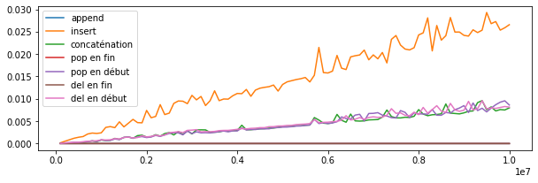

```python
import matplotlib.pyplot as plt

fig, ax = plt.subplots(figsize = (10, 3))

Llabels = ["append", "insert", "concaténation", "pop en fin", "pop en début", "del en fin", "del en début"]

for i in range(len(Lts)):
    plt.plot(Ln, Lts[i], label = Llabels[i])

plt.legend()
plt.show()
```

La même simulation, exécutée avec IDLE, prend environ $40$ secondes, et donne les résultats suivants :

[figure not shown]

On y fait les mêmes observations, à ceci près que les coefficients de proportionnalité pour les opérations `L.insert(0, 0)`, `L.pop(0)` et `del L[0]` sont du même ordre de grandeur.  
Le temps de la simulation est de l'ordre de 40 s.  
Le script est disponible [ici](https://github.com/lbaille20/Info1A_2021-22/blob/main/TP12/003_append_%2B_insert_pop_del_v2.py).

**Q6**

En lien avec la question **Q5** de l'exercice 1, on cherche ici à examiner l'évolution du temps de calcul pour la somme et le produit de deux entiers, en fonction du nombre de chiffres de leur écriture en base 2

```python
## https://stackoverflow.com/questions/34162443/why-do-many-examples-use-fig-ax-plt-subplots-in-matplotlib-pyplot-python

from time import time, perf_counter
from random import randrange

temps_debut = time()

pmax = 100000
Lp, Lta, Ltm = [], [], []

p = 0
while p < pmax:
    p += pmax // 100
    Lp.append(p)
    a1, a2 = randrange(2**(p-1), 2**p), randrange(2**(p-1), 2**p)
    dmin = float('inf')
    for k in range(20):
        t0 = perf_counter()
        a1 + a2
        t1 = perf_counter()
        d = t1 - t0
        dmin = min(dmin, d)
    Lta.append(dmin)

    dmin = float('inf')
    for k in range(20):
        t0 = perf_counter()
        a1 * a2
        t1 = perf_counter()
        d = t1 - t0
        dmin = min(dmin, d)
    Ltm.append(dmin)

tsim = time() - temps_debut
print("Durée de la simulation :", tsim)
```

```
Durée de la simulation : 2.4250752925872803
```

**Q6.a**

Que fait ce programme ? (on pourra répondre en ajoutant des commentaires au programme).

...

*Q6.a corrigé*

Le programme calcule les temps d'exécution pour l'addition et la multiplication d'entiers, `a1` et `a2`, dont l'écriture comporte $p$ chiffres ($p$ bits), pour $p$ variant de $1000$ à $100000$, par pas de $1000$.  
Pour chaque valeur de $p$, on tire au hasard les valeurs des entiers $a_1$ et $a_2$, et on effectue $m=20$ mesures de temps pour l'addition $a_1+a_2$, et on garde le plus petit temps obtenu, `dmin`, que l'on enregistre dans la liste `Lta`.  
On fait de même pour la multiplication de $a_1$ et $a_2$, en enregistrant le résultat dans la liste `Ltm`.

**Q6.b**

Représenter graphiquement les résultats obtenus.  
Les résultats sont-ils en cohérence avec ce que l'on peut attendre ?

```python
import matplotlib.pyplot as plt

...
```

```
Ellipsis
```

...

*Q6.b corrigé*

- Représentation graphique

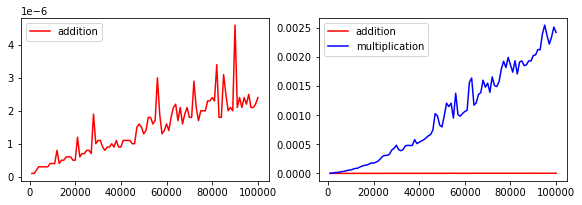

```python
import matplotlib.pyplot as plt

# https://matplotlib.org/3.5.0/api/_as_gen/matplotlib.pyplot.subplots.html
fig, (ax1, ax2) = plt.subplots(1, 2, figsize = (9.8, 3))

ax1.plot(Lp, Lta, 'r', label = "addition")
ax1.legend()

ax2.plot(Lp, Lta, 'r', label = "addition")
ax2.plot(Lp, Ltm, 'b', label = "multiplication")
ax2.legend()
plt.show()
```

- analyse

```python
max(Lta)
```

```
4.600000011123484e-06
```

Quant à la multiplication, sa complexité semble quadratique, *i.e.* en $O(p^2)$ où $p$ est le nombre de chiffres (bits) en base 2 des deux entiers multipliés.

Par analogie avec les algorithmes d'addition et de multiplication en base 10 (ce sont les mêmes en base 2), on attend une complexité linéaire, $O(p)$, pour l'addition, et quadratique, en $O(p^2)$ pour la multiplication, $p$ désignant le nombre de chiffres des nombres à additionner ou multiplier.

**Q6.c**

Vérifier, graphiquement, que les rapports des temps d'exécution de la multiplication (liste `Ltm`) sur les nombres de bits des entiers multipliés (liste `Lp`) ne sont pas bornés, tandis que les rapports des temps d'exécution sur nombre de bits le sont.  
Conclure.  
*On construira ces deux listes de rapports, `Ltm_sur_p` et `Ltm_sur_p2`, à l'aide de compréhensions de listes.*

*Q6.c corrigé*

On construit par compréhension de liste, la liste `Ltm_sur_p` des rapports $\frac{t_i}{p_i}$, et la liste `Ltm_sur_p2` des rapports $\frac{t_i}{p_i^2}$.

```python
Ltm_sur_p = [Ltm[i] / Lp[i] for i in range(len(Lp))]
Ltm_sur_p2 = [Ltm[i] / Lp[i] ** 2 for i in range(len(Lp))]
```

En traçant la représentation graphique des temps de calcul, $t_i$, divisés par $p_i$, ou de $p_i^2$, on peut examiner, en notant $T_m(p)$ la complexité de la multiplication de deux entiers de $p$ bits, si les rapports $\frac{T_m(p)}{p}$ ou $\frac{T_m(p)}{p^2}$ sont bornés, ce qui vérifiera, dans le premier cas, que la complexité de la multiplication, $T(p)$, est en $O(p)$, et dans le second cas, en $O(p^2)$.

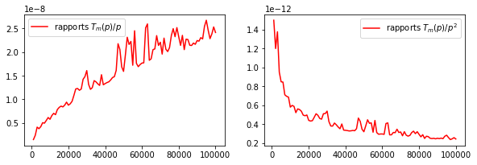

```python
import matplotlib.pyplot as plt

# https://matplotlib.org/3.5.0/api/_as_gen/matplotlib.pyplot.subplots.html
fig, (ax1, ax2) = plt.subplots(1, 2, figsize = (9.8, 3))

ax1.plot(Lp, Ltm_sur_p, 'r', label = "rapports $T_m(p)/p$")
ax1.legend()

ax2.plot(Lp, Ltm_sur_p2, 'r', label = "rapports $T_m(p)/p^2$")
ax2.legend()
plt.show()
```

On constate bien que les rapports $\frac{T_m(p)}{p^2}$ sont bornés, tandis que les rapports $\frac{T_m(p)}{p}$ ne le sont pas, ce qui est cohérent avec une complexité de la multiplication en $O(p^2)$.

On peut rechercher aussi (hors-programme en informatique) la meilleure approximation des valeurs obtenues par un polynome de degré 2 :

```
[-1.03294911e-04  1.42485608e-08  1.15577239e-13]
```

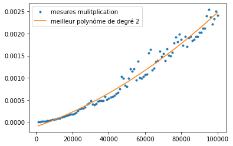

```python
# https://fr.wikibooks.org/wiki/Python_pour_le_calcul_scientifique/Polyn%C3%B4mes
import numpy.polynomial.polynomial as nppol

p = nppol.polyfit(Lp, Ltm, 2) # régression polynomiale de degré 2
print(p)

fig, ax = plt.subplots()
plt.plot(Lp, Ltm, ".", label = "mesures mulitplication")
plt.plot(Lp, nppol.polyval(Lp, p), label = "meilleur polynôme de degré 2")

plt.legend()
plt.show()
```

La même simulation, exécutée avec IDLE, permet de pousser jusqu'à une valeur maximale de $p$ égale à $10^6$, et on obtient les résutats suivants :

[figure not shown]

On constate que la complexité de l'addition apparaît cette fois comme linéaire par rapport au nombre de bits des entiers additionnés, et la complexité de la multiplication toujours quadratique.

En notant $T_a(p)$ la complexité de l'addition, et en traçant la représentation graphique des valeurs $\frac{T_a(p)}{p}$, on constate que ces rapports sont bornés, ce qui est cohérent avec une complexité linéaire, en $O(p)$, de l'addition.  
On observe à nouveau que les rapports $\frac{T_m(p)}{p^2}$ sont bornés, ce qui reste cohérent avec une complexité quadratique de la multiplication.

[figure not shown]

Le temps de la simulation est de l'ordre de 1 minute 30 secondes.  
Le script est disponible [ici](https://github.com/lbaille20/Info1A_2021-22/raw/main/TP12/002_addition_produit_entiers.py).

# Partie II $\quad$ Analyses de complexité

Dans cette partie, on aborde les attendus du programme en matière de calcul de complexité.

On présentera des résultats de simulations, mais seulement à titre illustratif.

Les programmes utilisés pour les simulations ont été exécutés dans IDLE et sont disponibles au téléchargement, à titre de curiosités.

## Exercice 3 $\quad$ Complexité linéaire

**Q1**

Redonner l'algorithme de calcul de la somme des éléments d'une liste d'entiers ou de flottants, implémenté à l'aide d'une boucle `while` dans une fonction `somme(L)`.

Annoter l'algorithme par le nombre d'opérations élémentaires effectués par chaque ligne du code

Calculer sa complexité en fonction du nombre d'éléments de la liste $L$.

*Q1 corrigé*

```python
def somme(L):
    n = len(L) # deux opérations élémentaires (comptent pour deux unités de temps) : lecture de len(L), affectation
    s = 0 # 1 unité de temps (affectation)
    i = 0 # 1 unité de temps (affectation)
    while i < n: # 1 unité de temps (comparaison de deux entiers)
        s = s + L[i] # 3 opérations élémentaires (3 unité de temps) (accès à une valeur dans une liste,
                     # addition de deux valeurs numériques, affectation)
        i = i + 1 # 2 unités de temps (addition, affectation)
    return s
```

- Calcul de complexité :

On estime la complexité temporelle, $T(n)$, en fonction du nombre d'éléments dans la liste, $n={\rm len}(L)$ (taille de l'instance $L$).
La somme est pour la répétition des opérations élémentaires du corps de la boucle `while`.
On compte chaque opération élémentaire (*opération dont le temps d'exécution est indépendante des objets auquels elle s'applique*) pour une unité de temps.
Le dernier 1 ajouté est pour la dernière incrémentation de l'indice $i$ allant avec le dernier test `i < n`, évalué à `False`, qui fait que la boucle termine. $$T(n)=2+1+1+\left(\sum_{i=0}^{n-1}1 + 3 + 2\right) + 1 = 5 + \left(\sum_{i=0}^{n-1}6\right) = 5 + n\times 6 = 6n + 5 = O(n) .$$

**Q2**

Redonner l'algorithme de copie superficielle d'une liste, implémenté à l'aide d'une boucle `for` dans une fonction `copie(L)`.

Calculer sa complexité en fonction du nombre d'éléments de la liste $L$, on ne détaillera pas les unités de temps relatives à chaque opération élémentaire, mais on comptera pour un temps constant chaque groupe d'opérations élémentaires.

*Q2 corrigé*

```python
def copie(L):
    L1 = [] # deux opérations élémentaires : instanciation d'une liste vide, affectation
    for i in range(len(L)): # opérations en temps constant : lecture de len(L) (une seule fois au départ de la boucle),
                            # gestion de l'indice de boucle : initialisation (une fois), incrémentation
                            # et test i < len(L) (une fois par itération),
                            # terminaison de la boucle : un dernière incrémentation et un dernier test (une fois)
        L1.append(L[i]) # deux opérations élémentaires : lecture de L[i], ajout par append
    return L1
```

- Calcul de complexité :

On estime la complexité temporelle, $T(n)$, en fonction du nombre d'éléments dans la liste, $n={\rm len}(L)$ (taille de l'instance $L$).
On compte pour une constante $c_1$ les opérations élémentaires n'ayant lieu qu'une fois, et pour une constante $c_2$ les opérations élémentaires répétées à chaque itération. $$T(n)=c_1+\sum_{i=0}^{n-1}c_2 = c_1 + c_2.n = O(n) .$$

La complexité de la copie superficielle d'une liste est en $O(n)$ où $n={\rm len}(L)$.

## Exercice 4 $\quad$ Meilleur et pire cas à taille d'instance donnée

**Q1**

Faire le même travail qu'à l'**exercice 1 Q1**, pour la recherche du maximum d'une liste non vide `L`, implémentée sous la forme d'une fonction `rechmax(L)`.  
Peut-on distinguer un meilleur et un pire cas (pour un nombre $n$ donné d'éléments dans la liste) ?  
Si oui, caractériser ces meilleur et pire cas et donner la complexité dans ces cas.

*Q1 corrigé*

```python
def rechmax(L):
    vmax = L[0] # 2 unités de temps (accès à L[0], affectation)
    n = len(L) # 2 unités de temps : lecture de len(L), affectation
    i = 1 # 1 unité de temps (affectation)
    while i < n:# 1 unité de temps (comparaison de deux entiers)
        if L[i] > vmax:# 2 unités de temps (lecture de L[i], comparaison de deux valeurs numériques)
            vmax = L[i]# 2 unités de temps (lecture de L[i], affectation)
        i = i + 1 # 2 unités de temps (addition, affectation)
    return vmax
```

- Calcul de complexité

La valeur de $n={\rm len}(L)$ est supérieure ou égale à 1, car la liste doit être supposée non vide.  
La complexité varie selon que le test `L[i] > vmax` est évalué à `True` ou `False`.

1. Si le test `L[i] > vmax` est évalué à `True` dans tous les cas : $$T(n)=2+2+1+\left(\sum_{i=0}^{n-1}1 + 2 + 2 +2\right) + 1 \quad \text{(le dernier + 1 pour la terminaison de la boucle while)}$$ $$ T(n) = 6 + \left(\sum_{i=1}^{n-1}7\right) = 6 + (n-1) \times 7=7n-1. $$
2. Si le test `L[i] > vmax` est évalué à `False` dans tous les cas : $$T(n)=2+2+1+\left(\sum_{i=1}^{n-1}1 + 2 +2\right) + 1 = 6 + \left(\sum_{i=1}^{n-1}5\right) = 6 + (n-1) \times 5=5n+1. $$
3. Dans tous les cas, la complexité est fonction du nombre de fois où le test `L[i] > vmax` est évalué à `True`, si on note $\varepsilon_i=1$ si le test est évalué à `True` lors de l'itération d'indice $i$, et $\varepsilon_i=0$ s'il est évalué à `False`, et $m$ le nombre de fois où ce test est évaluéà `True`, on a : $$T(n)=2+2+1+\left(\sum_{i=1}^{n-1}1 + 2 + 2.\varepsilon_i+2\right) + 1 = 6 + \left(\sum_{i=1}^{n-1}5+2\varepsilon_i\right) = 7 + 3(n-1) +2m =5n+2m+1. $$

Dans le cas général, examiné en 3. ci-dessus, la complexité, $T(n)$, vérifie $$ T_{\rm meilleur}(n)\leqslant T(n)\leqslant T_{\rm pire}(n) $$ et **le rapport $\frac{T(n)}{n}$ est borné dans tous les cas, donc, la complexité est linéaire dans tous les cas.**

**Q2**

On s'intéresse à la complexité de la recherche d'une valeur dans une liste.

**Q2.a $\quad$ recherche séquentielle dans une liste**

Faire le même travail qu'en **Q1**, pour la recherche d'une valeur $v$ dans une liste $L$, implémentée sous la forme d'une fonction `rechsimple(L, v)`, implémentée à l'aide d'une boucle `while` terminant dès que la valeur cherchée est trouvée ou, sinon, lorsque la fin de liste est atteinte et renvoyant `True`ou `False` selon que $v\in L$ ou non.

*Q2.a corrigé*

```python
def rechsimple(L, v):
    n = len(L) # deux opérations élémentaires (comptent pour deux unités de temps) : lecture de len(L), affectation
    i = 0 # 1 unité de temps (affectation)
    while i < n and L[i] != v: # 4 unité de temps (comparaison de deux entiers, accès à L[i], comparaison
                               # de deux valeurs, opération and entre deux booléens)
        i = i + 1 # 2 unités de temps (addition, affectation)
    return s
```

- Calcul de complexité

La complexité dépendra du fait de la présence ou non de la valeur cherchée dans la liste, et si elle est présente, de sa position dans la liste.

1. Si la valeur $v$ n'est pas présente dans la liste, alors la boucle `while` exécute $n={\rm len}(L)$ itérations, et on a : $$T(n)=2+1+\left(\sum_{i=0}^{n-1}4 + 2\right) + 1 \quad \text{(le dernier + 1 pour la terminaison de la boucle while)}$$ $$ T(n) = 4 + \left(\sum_{i=0}^{n-1}6\right) = 4 + n \times 6=6n+4. $$ *Note : lorsque la boucle `while` termine, en vertu de l'**évaluation paresseuse des booléens**, seul le test `i < n` est exécuté, car, évalué à `False`, le résultat de l'opération `and` est assuré d'être `False` et Python n'exécute pas le test `L[i] != v` (ce qui est heureux car $i$ valant alors ${\rm len}(L)$, une erreur `IndexError: list index out of range` serait déclenchée.*
2. Si la valeur $v$ est présente dans la liste en position $p$, $0\leqslant p<n={\rm len}(L)$, alors la boucle `while` exécute $p-1$ itérations, et on a : $$T(n)=2+1+\left(\sum_{i=0}^{p-1}4 + 2\right) + 4 \quad \text{(le dernier + 4 pour la terminaison de la boucle while)}$$ $$ T(n) = 7 + \left(\sum_{i=0}^{p-1}6\right) = 6p+7. $$ *Note : lorsque la boucle `while` termine, le test `i < n` est exécuté et évalué à `True`, et le test `L[i] != v` est exécuté et évalué à `False` et l'opération `and` est exécutée et évaluée à `False`.*

On peut distinguer un meilleur cas, qui correspond au cas n°2, lorsque $p=0$, *i.e.* la valeur cherchée est en position zéro dans la liste, auquel cas, aucune itération de la boucle `while` n'a lieu, et la complexité est $$ T_{\rm meilleur}(n)=6\times 0 + 7 = 7=O(1) $$

Dans tous les autres cas, y compris le cas n°2 avec $p=n-1$ où $T(n)=6(n-1)+7=6n+1$, on a $$ T_{\rm meilleur}(n)=7\leqslant T(n)\leqslant T_{\rm pire}(n)=6n+4. $$ On peut conclure en disant que **la complexité de la recherche séquentielle d'une valeur dans une liste, en fonction du nombre $n$ d'éléments dans la liste, est au pire linéaire,** i.e. **en $O(n)$ et au mieux constante, ,** i.e. **en $O(1)$.**

**Q2.b $\quad$ recherche dichotomique dans une liste triée**

- Rappeler l'algorithme de recherche dichotomique dans une liste triée, sous la forme d'une fonction `rechdicho(L, a, b, v)`, dans une implémentation itérative opérant sur les indices, renvoyant un booléen indiquant si la valeur est ou non dans la liste.  
  La recherche d'une valeur $v$ dans une liste $L$, se fera par l'appel `rechdicho(L, 0, len(L), v)`.  
  La recherche se poursuivra, au fil des itérations, dans la portion de liste $L[a:b] = [L[a], L[a + 1], \ldots, L[b-1]]$, et se terminera lorsque la valeur aura été trouvée ou lorsque la portion de liste à explorer sera vide.
- Distinguer un meilleur et pire cas, à taille d'instance ($n={\rm len}(L)$) donnée, et évaluer la complexité dans ces deux cas.  
  Dans les deux cas, on ne détaillera pas les opérations élémentaires prises en compte, mais on comptera pour une constante les blocs d'opérations élémentaires.  
  On ne cherchera pas à calculer exactement la complexité, mais à en donner, dans les deux cas, une **majoration pertinente par une fonction de $n$**.  
  **On décrira à quelles situations correspondent les meilleurs et pires cas.**

*Q2.b corrigé*

```python
def rechdicho(L, a, b, v):
    while a < b:
        m = (a + b ) // 2
        if L[m] == v:
            return True
        elif L[m] < v:
            b = m
        else:
            a = m + 1
    return False
```

- Calcul de complexité

Parmi les opérations exécutées lors d'une itération de la boucle `while`, on ne trouve que des opérations élémentaires.  
Le nombre d'opérations élémentaires exécutées varie selon le résultat des comparaisons entre `L[m]` et `v`, mais leur nombre peut être majoré par une constante que l'on notera $c$.

*On peut distinguer un meilleur cas, à taille donnée, $n$, pour la liste, qui est le cas où la valeur cherchée est trouvée à la première itération,* *i.e.* *est trouvée en position $m= n\,//\, 2$.*  
**Dans le meilleur cas**, la complexité est $T(n)$ majorée par la constante $c$, indépendante de $n={\rm len}(L)$ et donc $T(n)=O(1)$.

En dehors de ce meilleur cas, la complexité dépend du nombre d'itérations de la boucle `while`.  
Si la valeur $v$ est présente dans la liste, la boucle `while` terminera prématurément sur un `return True`, sinon, la boucle `while` ira jusqu'à son terme, *i.e.* jusqu'à ce que `a < b` soit évalué à `False`.  
On en déduit que *le pire cas correspond au cas où la valeur cherchée n'est pas présente dans la liste.*

Si on note $q_n$ le nombre d'itérations de la boucle `while` lorsque $v\notin L$, on peut donner pour la complexité la majoration suivante : $$T(n)\leqslant c_0 + n_{L,v}.c,$$ où $c_0$ correspond à l'exécution du dernier test qui signe la terminaison de la boucle, et $c$ est un majorant pour la compléxité des opérations élémentaires exécutées lors d'une itération.

Il reste à donner une majoration du nombre d'itérations $q_n$ lorsque $v\notin L$.

On rappelle que le nombre d'éléments dans une portion de liste $L[a:b]$, avec $0\leqslant a \leqslant b<{\rm len}(L)$, est égal à $b-a$.  
Par ailleurs, si au début d'une itération $b-a>0$ est pair, *i.e.* de la forme $b-a=2p$ avec $p\geqslant 1$, alors, $m = (a + b) \, // \, 2=(2a+2p) \, //\, 2=a+p$ et :

- si $L[m]<m$, la recherche se poursuit dans la portion de liste $L[a:m]$ de longueur $m-a=(a+p)-a=p=\frac{b-a}{2}$ ;
- si $L[m]>m$, la recherche se poursuit dans la portion de liste $L[m+1:b]$ de longueur $$b-(m+1) =(a+2p)-(a+p+1)= p-1<p=\frac{b-a}{2}$$,

et si au début d'une itération $b-a>0$ est impair, *i.e.* de la forme $b-a=2p+1$ avec $p\geqslant 0$, alors, $m = (a + b) \, // \, 2=(2a+2p+1) \, //\, 2=a+p$ et :

- si $L[m]<m$, la recherche se poursuit dans la portion de liste $L[a:m]$ de longueur $m-a=(a+p)-a=p<\frac{b-a}{2}$ ;
- si $L[m]>m$, la recherche se poursuit dans la portion de liste $L[m+1:b]$ de longueur $b-(m+1) =(a+2p+1)-(a+p+1)= p<\frac{b-a}{2}$.

Ainsi, dans tous les cas, si on note, avant toute itération, $(a_0, b_0)=(a, b)$, à l'issue de l'itération numéro $i$, $i\geqslant 1$, on peut démontrer, par récurrences, que la recherche, si elle se poursuit, se poursuit dans une portion de liste $L[a_i:b_i]$ de longueur $b_i-a_i\leqslant \frac{b-a}{2^i}$.

Or : $$0\leqslant \left(\frac{b-a}{2^i}<1\right) \Longleftrightarrow\left(b-a<2^i\right) \Longleftrightarrow\left(\ln (b-a)<i.\ln(2)\right) \Longleftrightarrow\left(i>\log_2(b-a)\right).$$

Si on note $i_0$ le plus petit entier $i$ tel que $i>\log_2(b-a)$, *i.e.* $i_0=\lfloor\log_2(b-a)\rfloor+1$, il est assuré que les nombre d'itérations de la boucle `while` n'excède pas la valeur $i_0$, *i.e.* le nombre d'itérations de la boucle `while`, $q_n$, lorsque la valeur $v$ n'appartient pas à la liste $L$, est tel que, comme $n={\rm len}(L)=b-a=v_0-a_0$ : $$n_q\leqslant \lfloor\log_2(b-a)\rfloor+1\leqslant \log_2(b-a)+1.$$

On en conclut, comme $n={\rm len}(L)=b-a$, que, **dans le pire cas, la complexité, $T(n)$, de la recherche dichotomique dans une liste triée à $n$ élément est telle que $$T(n)\leqslant \log_2(n)$$** et donc que **la complexité dans le pire est logarithmique, *i.e.* $T(n)=O(\ln (n))$.**

## Exercice 5 $\quad$ Complexité quadratique (tri sélection et tri insertion)

**Q1 $\quad$ Tri sélection**

On redonne l'implémentation suivant du tri sélection (expliquée au **TP10 Exercice 1 Q2**).

```python
def tri_selection2(L):
    for i in range(len(L) - 1):
        jmin = i
        for j in range(i + 1, len(L)):
            if L[j] < L[jmin]:
                jmin = j
        tmp = L[i]
        L[i] = L[jmin]
        L[jmin] = tmp
```

**Q1.a**

Déterminer la complexité de l'algorithme de tri sélection dans cette implémentation.  
On recherchera s'il existe des meillleurs et pires cas, et on les qualifiera s'il en existe.  
On évaluera la complexité dans ces cas s'ils existent.  
On concluera sur la complexité dans le cas général.

*Q1.a corrigé*

On s'intéresse à la complexité de l'algorithme en fonction de la longueur de la liste, $n={\rm len}(L)$.
L'algorithme peut être résume en une boucle `for`.
Si on note $c_0$ la complexité des opérations élémentaires exécutées une seule fois (lecture de ${\rm len}(L)$, opérations de terminaison de la boucle `for`) et $C(i)$ la complexité de l'itération d'indice $i$ de la boucle `for`, on a : $$ T(n)=c_0+\sum_{i=0}^{n-2}C(i). $$ *Note : **pour la suite, on pourra de façon générale agréger la complexité constante $c_0$ à la complexité de la boucle `for`, cette dernière ne pouvant pas être moins qu'en $O(1)$, i.e. constante.***

On peut décomposer la complexité $C(i)$ en des opérations élémentaires exécutées une fois lors d'une itération de la boucle `for`, de complexité constante, $c_1$, et des opérations élémentaires exécutées lors de l'itération d'indice $j$ de la boucle `while`, dont on peut noter la complexité $D(i, j)$.
On peut alors écrire : $$T(n)= c_0+\sum_{i=0}^{n-2}\left(c_1+\sum_{j=i+1}^{n-1}D(i, j)\right).$$

La complexité $c_1$ inclut les instructions `jmin = i`, `tmp = L[i]`, `L[i] = L[jmin]`, `L[jmin] = tmp`, l'incrémentation de l'indice $i$ et le test $i<n$ (les deux, une fois par itération de la boucle `for` d'indice $i$), la lecture de ${\rm len}(L)$ à l'initialisaton de la boucle `for` d'indice $j$, la dernière incrémentation et le dernier test sur $j$ lors de la terminaison de la boucle `for` d'indice $j$.

La complexité $D(i, j)$ dépend de la composition de la portion de liste $L[i+1:n]$, qui détermine le nombre de fois où le test `L[j] < L[jmin]` est évalué à `True`, auquel cas la variable `jmin` est actualisée par `jmin = j`.  
Dans tous les cas, le nombre d'opérations élémentaires exécutées lors d'une itération de la boucle d'indice $j$, hormis l'actualisation `jmin = j`, est constant et la complexité, constante, de ces opérations peut être notée $c_2$.  
Si l'actualisation `jmin = j` a lieu, il convient de rajouter une opération élémentaire à la complexité $c_2$, qui devient alors égale à $c_2+1$.

On peut ainsi distinguer un meilleur cas :

1. un meilleur cas : celui où l'actualisation `jmin = j` n'a jamais lieu, on a alors à chaque itération de la boucle $j$ une complexité $c_2$, ce qui advient si la valeur en $L[i]$ est le minimum de la portion $L[i:]=L[i:n]$.
2. un pire cas : celui où l'actualisation `jmin = j` a jamais lieu à chaque itération de la boucle $j$, chaque itération ayant alors une complexité $c_2+1$, ce qui advient si pour tout $j\in[\![i+1, n-1]\!]$, $L[j-1]> L[j]$.

Si on définit une variable $\varepsilon_{i,j}$ égale à $1$ si pour une valeur donnée de $i$ et une valeur donnée de $j\in\in[\![i+1, n-1]\!]$ on a $L[j] < L[jmin]$, et à zéro sinon, la complexité du tri par sélection a pour complexité, de façon générale : $$ T(n)=c_0+\sum_{i=0}^{n-2}\left(c_1+\sum_{j=i+1}^{n-1}c_2 + \varepsilon_{i,j} \right),$$ et l'encadrement suivant : $$ c_0+\sum_{i=0}^{n-2}\left(c_1+\sum_{j=i+1}^{n-1}c_2 \right) \leqslant T(n) \leqslant c_0+\sum_{i=0}^{n-2}\left(c_1+\sum_{j=i+1}^{n-1}c_2+1 \right) $$

Le minorant est atteint si pour tout $i$ le minimum de $L[i:]$ est en $L[i]$, *i.e.* si la liste est initialement triée dans l'ordre croissant (*i.e* initialement déjà triée), c'est là le **meilleur cas pour $n$ donné**.  
Le majorant est atteint plus difficile à cerner, car il faut qu'à chaque itération d'indice $i$, $i\in [\![0, n-2]\!]$, le $(i+1)^{ème}$ minimum de $L$ soit en dernière position dans la fin de liste $L[i:]$. Les minimums trouvés à chaque itération d'indice $i$ étant échangés avec la valeur en position $i$, cette situation advient si, en notant $[m_1, m_2, \ldots, m_n]$ la liste $L$ une fois triée, la liste $L$ dans son état initial est la liste $[m_2, m_3,\dots, m_{n-1}, m_n, m_1]$, c'est là le **pire cas pour $n$ donné**.

On a alors :

- pour le meilleur cas, la complexité $$\left(T_{\rm meilleur}(n) = c_0+\sum_{i=0}^{n-2}\left(c_1+\sum_{j=i+1}^{n-1}c_2 \right) = c_0+\sum_{i=0}^{n-2}\left(c_1+((n-1)-(i+1)+1).c_2\right) = c_0+\sum_{i=0}^{n-2}\left(c_1+(n-i-1).c_2\right)\right)$$ $$\Longleftrightarrow\left( T_{\rm meilleur}(n) = c_0+\sum_{i=0}^{n-2}\left((n-1).c_2 + c_1) - c_2.i\right) = c_0+((n-1).c_2 + c_1).\left(\sum_{i=0}^{n-2}1\right)-c_2.\left(\sum_{i=0}^{n-2}i\right) \right)$$ $$\Longleftrightarrow\left( T_{\rm pire}(n) = c_0+((n-1).c_2 + c_1).((n-2)-0+1)-c_2.\frac{(n-2)((n-2)+1)}{2} = c_0+(n-1)((n-1).c_2 + c_1)-\frac{(n-2)(n-1)}{2}.c_2 \right)$$ et donc $$T_{\rm meilleur}(n)= \frac{1}{2}c_2n^2+\left(c_1-\frac{1}{2}c_2\right)+(c_0-c_1+2c_2) =O(n^2).$$
- pour le pire cas, le calcul est le même, en remplaçant $c_2$ par $c_2+1$ : $$T_{\rm pire}(n)= \frac{1}{2}(c_2+1)n^2+\left(c_1-\frac{1}{2}(c_2+1)\right)+(c_0-c_1+2(c_2+1)) =O(n^2).$$

Comme, pour tout $n$, $T_{\rm meilleur}(n)\leqslant T(n) \leqslant T_{\rm pire}(n)$, on en conclut que, dans tous les cas, le rapport $\frac{T(n)}{n^2}$ est borné, et donc que, **la complexité du tri sélection est, dans tous les cas, quadratique,** *i.e.* **$T(n)=O(n^2)$.**

**Q1.b**

Reprendre le calcul de la complexité du tri sélection en se basant sur la complexité de la recherche de la position du minimum d'une liste. *On notera que cette approche permet une détermination bien plus rapide de la complexité du tri sélection.*

*Q1.b corrigé*

On rappelle l'implémentation suivante du tri sélection (**TP10 Exercice 1 Q2**) :

```python
def tri_selection1(L):
    for i in range(len(L) - 1):
        posmini = posmin(L, i)
        tmp = L[i]
        L[i] = L[posmini]
        L[posmini] = tmp
```

Dans cette implémentation, la complexité de l'algorithme de tri sélection en fonction de $n={\rm len}(L)$ peut se décomposer ainsi : $$T(n)=O(n) + \sum_{i=0}^{n-2}C(i)$$ où la contribution $O(n)$ correspond à la complexité de la boucle `for` et des opérations élémentaires d'affectation qu'elle comporte, tandis que la somme est la somme des complexité des recherches, pour chaque valeur de $i$, de la position du minimum au sein de la portion de liste $L[i:n]$.

Or les recherches de position du minimum se font en exécutant les lignes de code suivantes du corps de la fonction `posmin(L, i)` :

```python
def posmin(L, i):
    jmin = i
    for j in range(i + 1, len(L)):
        if L[j] < L[jmin]:
            jmin = j
    return jmin
```

lesquelles se résument à l'exécution d'un nombre constant, $c_0$, d'opérations d'opérations élémentaires en dehors de la boucle d'indice $j$ et la répétition ${\rm len}(L) - (i+1)$ fois d'un nombre d'opérations élémentaires, variant suivant le nombre de tests `L[j] < L[jmin]` évalués à `True`, mais compris entre deux constantes, $c_1<c'_1$.
Ainsi, dans tous les cas : $$\left(c_0+\sum_{j=i+1}^{n-1}c_1\leqslant C(i) \leqslant c_0+\sum_{j=i+1}^{n-1}c'_1 \right)\Longleftrightarrow \left(c_0+c_1\sum_{j=i+1}^{n-1}1\leqslant C(i) \leqslant c_0+c'_1\sum_{j=i+1}^{n-1}1 \right) .$$.

Comme il est connu que le nombre de termes dans la somme $\sum_{j=i+1}^{n-1}1$ est $(n-1)-(i+1)+1=n-i-1$, on a donc encore :

$$c_0+c_1(n-i-1)\leqslant C(i) \leqslant c_0+c'_1(n-i-1).$$

puis : $$\left(O(n) + \sum_{i=0}^{n-2}c_0+c_1(n-i-1) \leqslant T(n) \leqslant O(n) + \sum_{i=0}^{n-2}c_0+c'_1(n-i-1) \right) \Longleftrightarrow \left(O(n) + (c_0-c_1)\sum_{i=0}^{n-2}1+c_1\sum_{i=0}^{n-2}(n-i) \leqslant T(n) \leqslant O(n) + (c_0-c'_1)\sum_{i=0}^{n-2}1+c'_1\sum_{i=0}^{n-2}(n-i) \right) $$

Comme il est connu que $\sum_{i'=0}^{n-2}1=n-1=O(n)$ et $\sum_{i'=0}^{n-2}i'=\frac{(n-2)(n-1)}{2}=O(n^2)$, on a encore, dans tous les cas :

$$O(n) + (c_0-c_1)O(n)+c_1O(n^2) \leqslant T(n) \leqslant O(n) + (c_0-c'_1)O(n)+c'_1O(n^2). $$

D'où la conclusion, dans tous les cas : $$T(n)=O(n^2).$$

La même analyse pourrait être menée sur l'implémentation initialement considérée du tri sélection :

```python
def tri_selection2(L):
    for i in range(len(L) - 1):
        jmin = i
        for j in range(i + 1, len(L)):
            if L[j] < L[jmin]:
                jmin = j
        tmp = L[i]
        L[i] = L[jmin]
        L[jmin] = tmp
```

en notant $C(i)$ la complexité de l'exécution des lignes 2 à 6 (Affichage>Afficher/masquer les numéros de lignes pour afficher les numéros de ligne).

**Q2 $\quad$ Tri insertion**

On rappelle une implémentation du tri insertion (**TP10 Exercice 2 Q2**)

```python
def tri_insertion2(L):
    for i in range(1, len(L)):
        tmp = L[i]
        j = i
        while 0 < j and L[j - 1] > tmp:
            L[j] = L[j - 1]
            j = j - 1
        L[j] = tmp
```

Déterminer la complexité du tri insertion, en distinguant et décrivant, s'ils existent, les meilleurs et pires cas, et leurs complexités propres.

*Q2 corrigé*

Si on note $n_i$ le nombre d'itérations de la boucle `while`, et $c$ la complexité d'exécution d'une itération de la boucle `while`, selon le nombre de tests nécessaires à la terminaison de la boucle `while`, toutes les opérations effectuées étant élémentaires, il existe des constantes, $a_1$, $a_2$, $b_1$, $b_2$, telles que, dans tous les cas, en notant $n={\rm len}(L)$ : $$ a_1+\sum_{i=1}^{n-1}\left(b_1+\sum_{k=1}^{n_i}c\right) \leqslant T(n) \leqslant a_2+\sum_{i=1}^{n-1}\left(b_2+\sum_{k=1}^{n_i}c\right) $$ ou encore $$ \left( a_1+\sum_{i=1}^{n-1}\left(b_1+n_i.c\right) \leqslant T(n) \leqslant a_2+\sum_{i=1}^{n-1}\left(b_2+n_i.c\right) \right) $$ $$ \Longleftrightarrow \left( a_1+b_1\sum_{i=1}^{n-1}1+c\sum_{i=1}^{n-1}n_i \leqslant T(n) \leqslant a_2+b_2\sum_{i=1}^{n-1}1+c\sum_{i=1}^{n-1}n_i \right) $$

Or le nombre $n_i$ d'itérations de la boucle `while` est égal au nombre de valeurs à décaler d'un rang vers la droite par la portion de liste $L[:i]$ au moment d'insérer la valeur $L[i]$, et on peut distinguer deux cas :

- cas n° 1 : le nombre de décalage est minimal, égal à zéro, si la valeur $L[i]$ est supérieure ou égale à toutes les valeurs déjà placées ;
- cas n° 2 : le nombre de décalage est maximal, égal $i$, si la valeur $L[i]$ est inférieure strictement à toutes les valeurs déjà placées.

On peut donc distinguer pour le tri insertion :

- un meilleur cas, dans lequel on est à chaque itération d'indice $i$ dans le cas n°1, ce qui advient si la liste est initialement déjà triée dans l'ordre croissant, auquel cas la complexité du tri est $T_{\rm meilleur}(n)$, telle que $$ \left( a_1+b_1\sum_{i=1}^{n-1}1+c\sum_{i=1}^{n-1}0 \leqslant T_{\rm meilleur}(n) \leqslant a_2+b_2\sum_{i=1}^{n-1}1+c\sum_{i=1}^{n-1}0 \right) \Longleftrightarrow \left( a_1+b_1(n-1) \leqslant T_{\rm meilleur}(n) \leqslant a_2+b_2(n-1) \right), $$ d'où l'on tire que $T_{\rm meilleur}(n)=O(n)$.
- un pire cas, dans lequel on est à chaque itération d'indice $i$ dans le cas n°2, ce qui advient si la liste est initialement déjà triée dans un ordre strictement décroissant, auquel cas la complexité du tri est $$ \left( a_1+b_1\sum_{i=1}^{n-1}1+c\sum_{i=1}^{n-1}i \leqslant T_{\rm pire}(n) \leqslant a_2+b_2\sum_{i=1}^{n-1}1+c\sum_{i=1}^{n-1}i \right) \Longleftrightarrow \left( a_1+b_1(n-1)+c\frac{(n-1)n}{2} \leqslant T_{\rm pire}(n) \leqslant a_2+b_2(n-1)+c\frac{(n-1)n}{2} \right) \Longleftrightarrow \left( a_1-b_1+(b_1-c)n+c\frac{1}{2}cn^2 \leqslant T_{\rm pire}(n) \leqslant a_2-b_2+(b_2-c)n+c\frac{1}{2}cn^2 \right) $$ d'où l'on tire que $T_{\rm pire}(n)=O(n^2)$.

En conclusion, **la complexité du tri par insertion est, dans le meilleur cas, lorsque la liste est initialement triée, en O(n), et dans le pire cas, lorsque la liste est initialement une suite de valeurs strictement décroissante, en $O(n^2)$.**

## Exercice 6 $\quad$ Complexité quasi-linéaire (tri fusion)

## Exercice 7 $\quad$ Complexité polynomiale (opération sur deux matrices carrées)

**Q1**

Redonner les trois façons de créer une liste de $n$ zéros entiers (par duplication, par compréhension de listes, à l'aide d'une boucle `for`).

*Q1 corrigé*

**Q2**

Donner quatre façons de créer un tableau de taille $n\times m$ dont tous les éléments sont des zéros entiers.  
On réutilisera les techniques mises en œuvre en question **Q1**, et on vérifiera que la modification de l'une des valeurs dans le tableau ne modifie pas les autres.

*Q2 corrigé*

**Q3**

On rappelle que la multiplication de deux matrices $A\in{\mathcal M}_{n,p}({\mathbb R})$ et $B\in{\mathcal M}_{q,r}({\mathbb R})$, dans cet ordre, est possible, si et seulement si $p=q$, et qu'alors la matrice $C=AB$ est de taille $n\times r$.

**Q3.a**

Définir, en retenant la méthode la plus concise donnée en **Q2**, une fonction `zeros(n, m)` renvoyant un tableau de séros entiers, représentant la matrice nulle de taille $n\times m)$.

```python
def zeros(n, m):
    return ...
```

Déterminer la complexité de cette fonction.

*Q3.a corrigé*

## Exercice 8 $\quad$ Complexité exponentielle

On rappelle la définition de la [suite de Fibonacci](https://fr.wikipedia.org/wiki/Suite_de_Fibonacci) :
$$\left\{ \begin{matrix} F_0=0 \; ; \, F_1=1\\ \forall\,n\in{\mathbb N}, \quad F_{n+2}=F_{n+1}+F_n \end{matrix} \right. $$

et une implémentation récursive du calcul de son terme de rang $n\geqslant 0$ :

```python
def fibo(n):
    ## cas de base
    if n == 0 or n == 1:
        return n
    ## cas général
    return fibo(n - 1) + fibo(n - 2)
```

qui permet, par exemple, le calcul de ses dix-sept premiers termes :

```python
for i in range(17):
    print('F(' + str(i) + ') =', fibo(i))
```

[output not shown]

## Exercice 9 $\quad$ Complexité hyper-exponentielle

## Exercice 10 $\quad$ Complexité en moyenne (tri-rapide)